# Explorando com R

### Produção de gráficos para diferentes variáveis

Podemos por exemplo, produzir todas as combinações possíveis de gráficos biplots com as 4 variáveis (colunas) numéricas do dataset Iris. Mais a frente deste tutorial ensinaremos como fazer gráficos, não se importe por enquanto com o plot produzido.

Criaremos uma função genérica primeiro, e então produziremos em escala.

```r
graf_generico <- function(dados, x1, y1, color1){

  col      <- names(dados)
  dados_aux <- dados[, c(x1, y1, color1)]
  colnames(dados_aux) <- c('X', 'Y', 'Color')

  plot <- ggplot(data = dados_aux, aes(x = X, y = Y, color = Color)) +
    geom_point() +
    labs(x = col[x1],
         y = col[y1])

  return(plot)
}

lista    <- list()
comb     <- combn(c(1:4), 2) # Combinações 2 a 2
qtd_comb <- ncol(comb)

print(comb)
```

```
##      [,1] [,2] [,3] [,4] [,5] [,6]
## [1,]    1    1    1    2    2    3
## [2,]    2    3    4    3    4    4
```

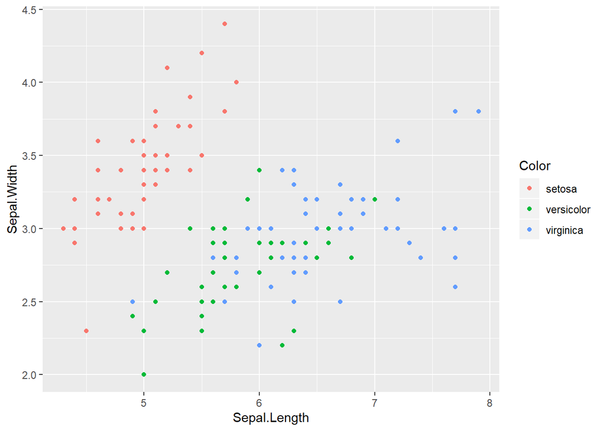

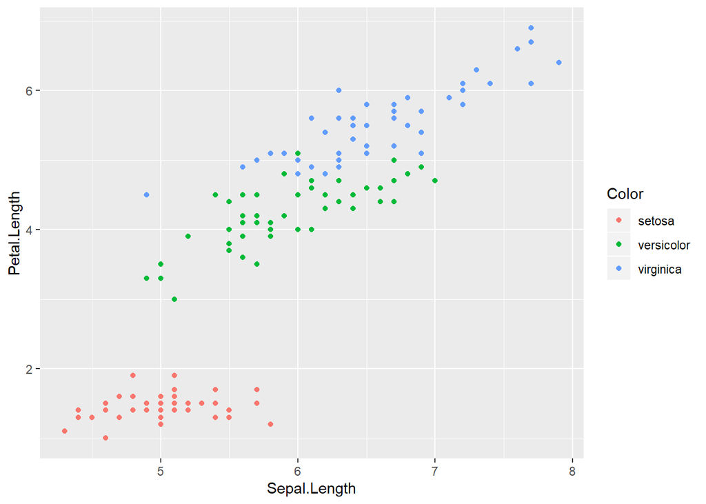

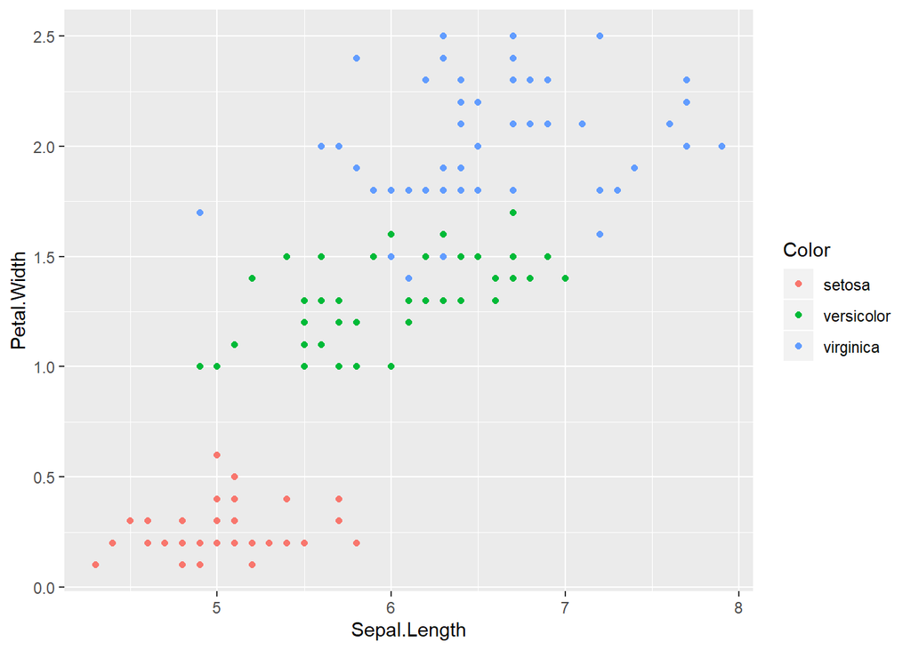

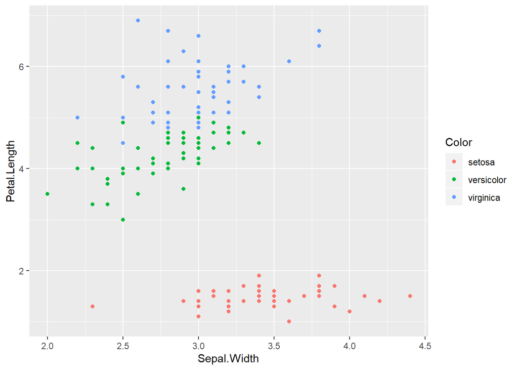

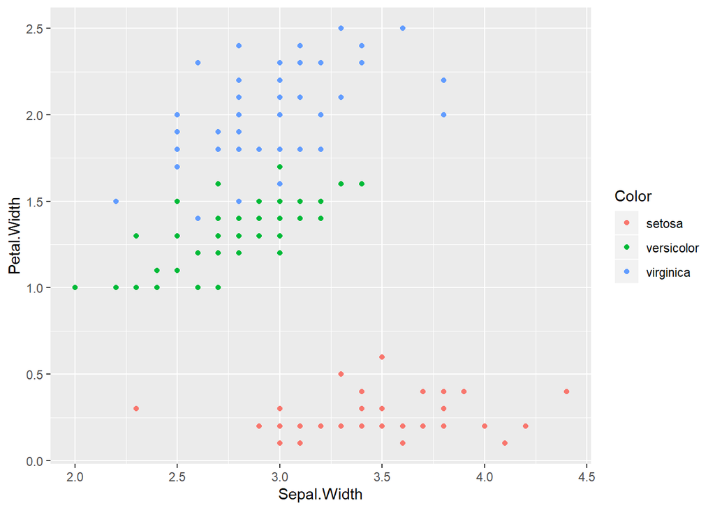

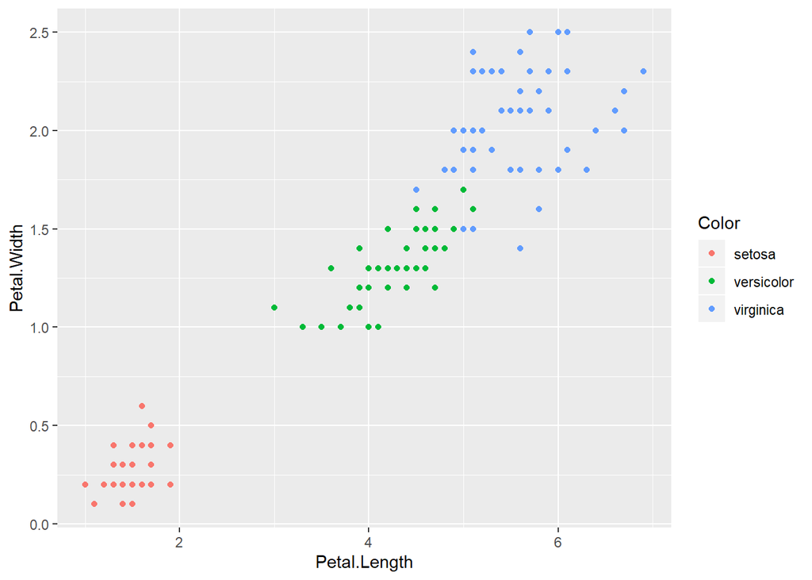

```r
for(i in 1:qtd_comb){
  x1 <- comb[1, i]
  y1 <- comb[2, i]
  lista[[i]] <- graf_generico(iris, x1, y1, 5)
}

print(lista)
```

Note que esse pedaço de código produziria tanto 1, 2, 3 , …, 1 milhão de gráficos.

Para apenas um ou dois gráficos, o esforço não valeria. Porém se você deseja fazer a mesma coisa algumas vezes repetidamente, é indiscutível o ganho que isso trás.